# S371: Lab 11

Lab Instructor: Katya Baldina (baldina@iu.edu)

2023-11-01

# Announcement

HW7 IS DUE THURSDAY (Nov. 2) 11.59 PM!

# Plots in R

Interchangeable terms:

- Plot
- Graph
- Chart

# Plots in R

Univariate graphs:

- For quantitative variable, create:
  - Histogram or Box Plot
- For categorical variable, create:
  - Bar Chart or Pie Chart***

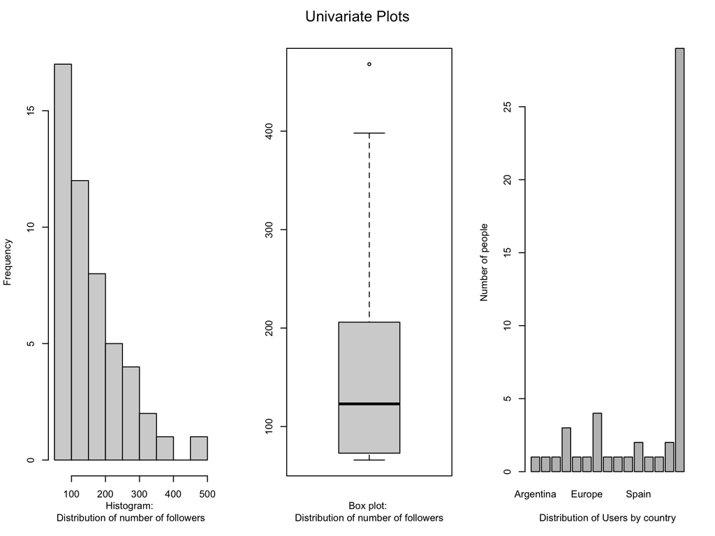

# Histogram

```r
hist(X)
```

You can add many options

`breaks` : specify the range and breaks of x-axis (or the number of breaks)

`xlim` : specify the range of x-axis

`main` : specify the main title

`ylab` : specify the y-axis label

`xlab` : specify the x-axis label

`col` : specify the color of the bar

# Histogram

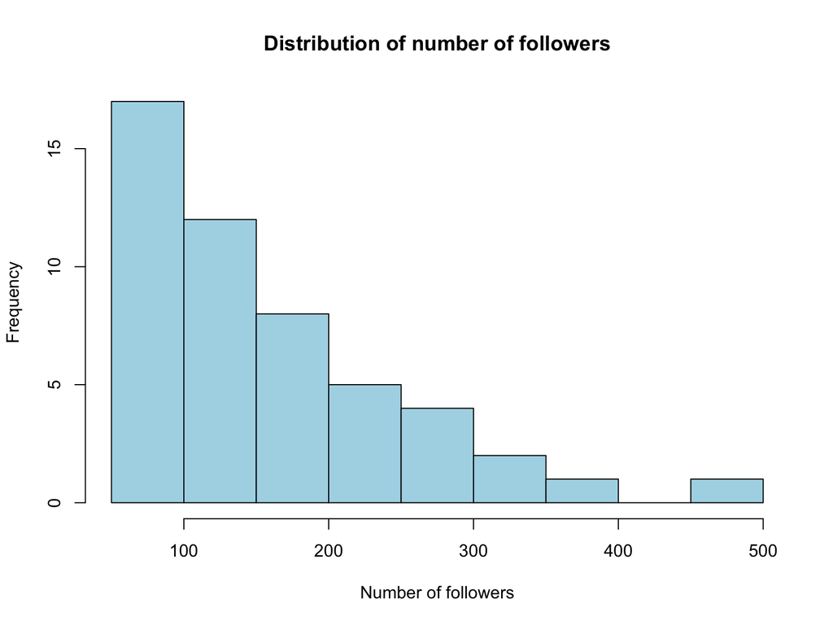

```r
hist(as.numeric(insta$Followers), main = "Distribution of number of followers",
     xlab = "Number of followers",
     col = 'lightblue')
```

# Box plot

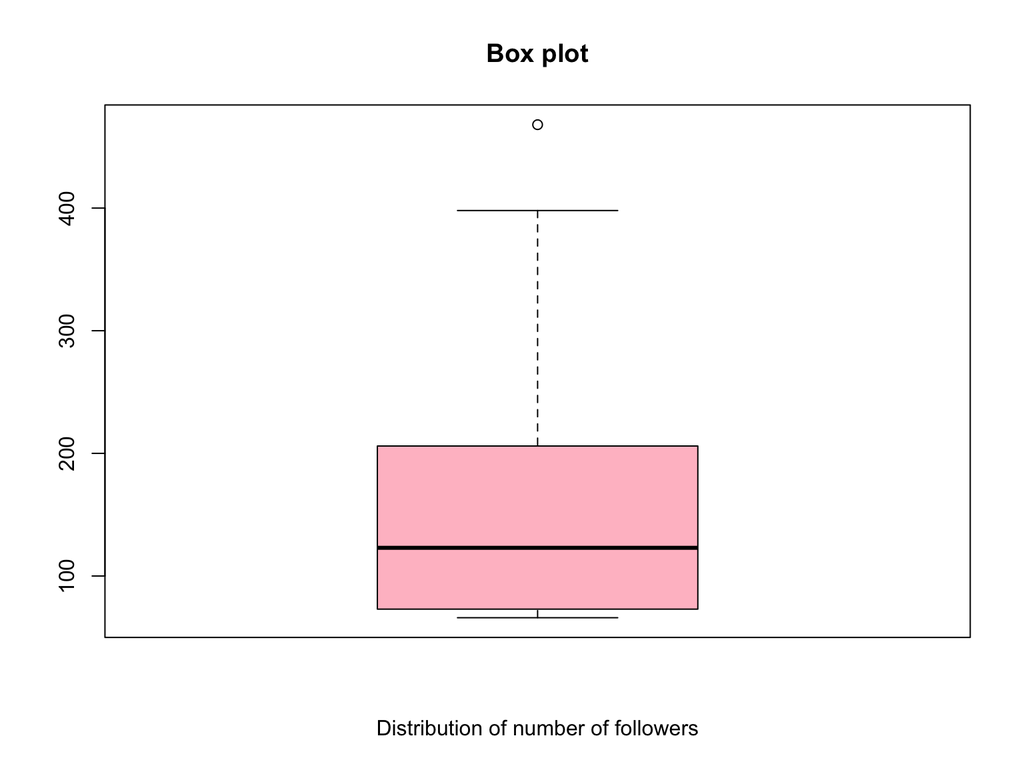

```r
boxplot(as.numeric(insta$Followers),
        xlab = "Distribution of number of followers",
        main="Box plot",
        col = "pink")
```

# Bar chart

To make a bar chart, you should construct a one- way table first

For example, make a one-way table for the variable Region based on the “instagramm2022.Rda” data file:

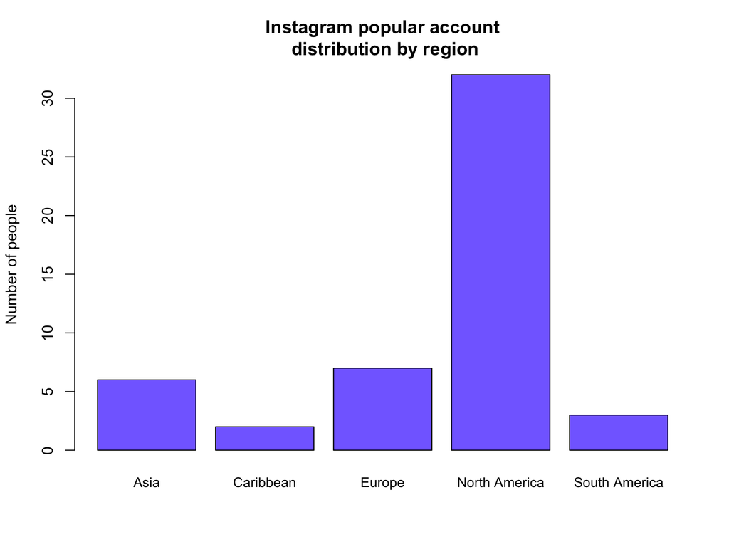

```r
onewaytable1 <- table(insta$Region)
barplot(onewaytable1,
        xlab="",
        ylab="Number of people",
        main = "Instagram popular account\n distribution by region",
        col = "slateblue1",
        cex.names=0.9)
```

# HW 7 Guide

There are two parts:

- Part 1: Q1 and Q2
- Part 2: Q3

I will walk through question 3 with you today

If you have questions about Part 1, feel free to ask me after the end of today’s lab

# HW 7 Guide

The data frame: instagram2022.Rda

This data contains 50 popular Instagram accounts with a list of variables

# HW 7 Guide

- Rank of account (based on number of followers)
- User name
- Owner
- The profession
- Country
- Personal vs. corporal account
- Industry
- Region
- Female

# HW 7 Guide

Line 20 and 21: These two lines create a custom R function called ctable() which shows column proportions

```r
ctable <- function(...,digits=2)
  round(addmargins(prop.table(table(...),margin=2),margin=1),digits)
```

For the purpose of this class, you don’t need to understand how it is done

You just need to run these two lines before running any lines below

Note: the first variable in the ctable() function goes to the row in the output. The second variable in the ctable() function goes to the column in the output.

# HW 7 Guide

Custom function: once these two lines have been run, you can use the R function ctable()

This line defines how the ctable() function works:

• It puts the two variables in the parentheses in to a table() command. Then put the table() command in a prop.table() command to make the output as proportion by column. Then put the prop.table() command in a addmargins() command to add column total. Lastly, the addmargins() command is put into the round() command to round off the output.

# HW 7 Guide

Line 28: load() command

This line loads the data frame (instagram2022.Rda) into RStudio

• If you have loaded this data frame through FileOpen File, then you can skip this line

# HW 7 Guide

Line 31: print() function

If you put down an R object which is a data frame within the parentheses, this function outputs the actual observations stored inside the data frame

# HW 7 Guide

Line 30: table() function

This line creates a bivariate table

You need to add an explanation of what this function does right above this function.

Line 32: ctable() function

This is the custom R function that professor creates on line 20 and 21

• You have to run line 20 and 21 first before running line 32

• The ctable() function gives you a bivariate table in column proportions

• Note: the first variable in the ctable() function goes to the row in the output. The second variable in the ctable() function goes to the column in the output.

# HW 7 Guide

You need to add an explanation of what this function does right above this function.

```r
# Add comment here
table(insta$Industry,insta$Region)
```

```
##
##                 Asia Caribbean Europe North America South America
##   Entertainment    0         0      1             6             0
##   Fashion          0         0      0             3             0
##   Film             3         0      0             3             0
##   Govt             0         0      0             1             0
##   Media            0         0      0             2             0
##   Music            2         2      1            15             1
##   Sports           1         0      5             2             2
```

```r
# Add comment here
ctable(insta$Industry,insta$Region)
```

```
##
##                 Asia Caribbean Europe North America South America
##   Entertainment 0.00      0.00   0.14          0.19          0.00
##   Fashion       0.00      0.00   0.00          0.09          0.00
##   Film          0.50      0.00   0.00          0.09          0.00
##   Govt          0.00      0.00   0.00          0.03          0.00
##   Media         0.00      0.00   0.00          0.06          0.00
##   Music         0.33      1.00   0.14          0.47          0.33
##   Sports        0.17      0.00   0.71          0.06          0.67
##   Sum           1.00      1.00   1.00          1.00          1.00
```

# HW 7 Guide

Line 46 and 49

These lines are incomplete

• You need to delete [ADD VARIABLE HERE]

• Read the comment on line 45. Then you know which variable should be put on line 46 to replace [ADD VARIABLE HERE]

```r
# Conditional table of accounts by Female and Region
ctable([ADD VARIABLE HERE], insta$Region)

# Table of accounts by Corporate and Region
table([ADD VARIABLE HERE], [ADD VARIABLE HERE])
```

# HW 7 Guide

```r
# Conditional table of accounts by Corporate and Region
## ADD CODE HERE
```

# HW 7 Guide

*b. What other variables are included in the ‘insta’ data frame? (5 points)*

List variables that are not mentioned in R script for the homework

*c. What are the dimensions of each of the 4 two-way tables (excluding conditional tables)? (8 points)*

```r
# Add comment here
table(insta$Industry,insta$Region)
```

```
##
##                 Asia Caribbean Europe North America South America
##   Entertainment    0         0      1             6             0
##   Fashion          0         0      0             3             0
##   Film             3         0      0             3             0
##   Govt             0         0      0             1             0
##   Media            0         0      0             2             0
##   Music            2         2      1            15             1
##   Sports           1         0      5             2             2
```

*Hint: How many rowsXcolumns in the table?*

# HW 7 Guide

You will find the answers to these questions by looking at your R script.

*d. Which industry has the most corporate accounts? (2 points)*

*e. Which industry is most evenly split between corporate and non-corporate accounts? (2 points)*

*f. Which industry is most popular in North America? South America? Europe? (6 points)*

*g. Which region(s) is the most male dominated? Which region(s) is the most female dominate? (4 points)*

*h. Which region has the most corporate accounts? (2 points)*

*i. Which region has the highest percentage of corporate accounts? (2 points)*

*j. Which region has the most different industry accounts in the top 50? (2 points)*

*k. Which region has the fewest? (2 points)*